# Dimensionality reduction techniques

## Overview of the data

Data set used in the following was build from United Nations Development Programme Human Development Report data which focused on evaluation of human development (length of life and health, knowledge, standard of living) and how gender inequality affects this development (female reproductive health, labour market and parliamentary gender representation).

Original data sets can be found here: http://hdr.undp.org/en/content/human-development-index-hdi and here:http://hdr.undp.org/sites/default/files/hdr2015_technical_notes.pdf Data preparation can be found in scripts create_human.R and further edits in human_edited.R.

Short description of the data set variables:

**SecEdRatioFM** - *calculated* female / male populations with secondary education in each country **LabForceRatioFM** - *calculated* ratio of labour force participation of females and males in each country **ExpecYearsEd** - Expected years of education **LifeExpec** - Life expectancy at Birth **GNI** - Gross national income per capita **MatMortRat** - Maternal mortality ratio **AdolecBirthRate** - Adolescent birth rate **RepresParl** - Percent representation in parlament

### Data exploration

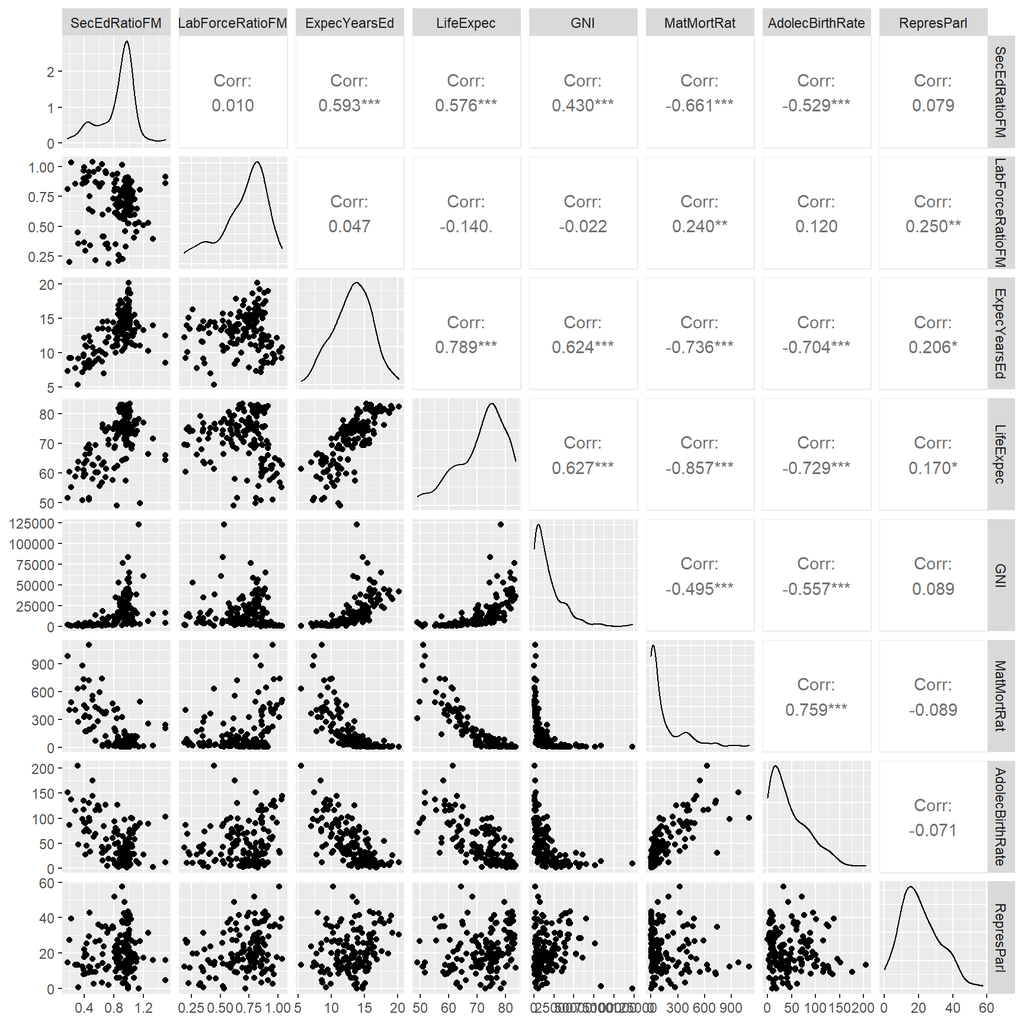

```r
#Read in the data
data <- read.csv("C:/Users/Localadmin_neimane/Desktop/Data Science/OpenDataScience/IODS-project/data/humanEdit.txt", sep="")

#Load packages
library(ggplot2)
library(GGally)
#Plot
ggpairs(data, lower = list(combo = wrap("facethist", bins = 20)))
```

Many of the explored variables are correlated. Highest correlation coefficient (-0.857) maternal mortality ratio and Life expectancy at Birth. In countries with high maternal mortality ratio it is expected that life will be shorter. Strong correlation can also be observed between Life expectancy at Birth & Expected years of education, Adolescent birth rate & Life expectancy at Birth, maternal mortality ratio & Expected years of education. Of the variables Expected years of education variable seem to follow *normal distribution*. While GNI and AdolecBirthRate seem to have *log normal* distribution. RepresParl appear to have *Poisson* distribution.And the rest perhaps follow *beta* distribution.

```r
#Summaries of the variables in the data set
summary(data)
```

```
##   SecEdRatioFM    LabForceRatioFM   ExpecYearsEd     LifeExpec
##  Min.   :0.1717   Min.   :0.1857   Min.   : 5.40   Min.   :49.00
##  1st Qu.:0.7264   1st Qu.:0.5984   1st Qu.:11.25   1st Qu.:66.30
##  Median :0.9375   Median :0.7535   Median :13.50   Median :74.20
##  Mean   :0.8529   Mean   :0.7074   Mean   :13.18   Mean   :71.65
##  3rd Qu.:0.9968   3rd Qu.:0.8535   3rd Qu.:15.20   3rd Qu.:77.25
##  Max.   :1.4967   Max.   :1.0380   Max.   :20.20   Max.   :83.50
##       GNI           MatMortRat     AdolecBirthRate    RepresParl
##  Min.   :   581   Min.   :   1.0   Min.   :  0.60   Min.   : 0.00
##  1st Qu.:  4198   1st Qu.:  11.5   1st Qu.: 12.65   1st Qu.:12.40
##  Median : 12040   Median :  49.0   Median : 33.60   Median :19.30
##  Mean   : 17628   Mean   : 149.1   Mean   : 47.16   Mean   :20.91
##  3rd Qu.: 24512   3rd Qu.: 190.0   3rd Qu.: 71.95   3rd Qu.:27.95
##  Max.   :123124   Max.   :1100.0   Max.   :204.80   Max.   :57.50
```

## Principal Component Analysis

First of all we will look at the PCA when the data has not been scaled. Afterwards we will scale the data and run the analysis again.

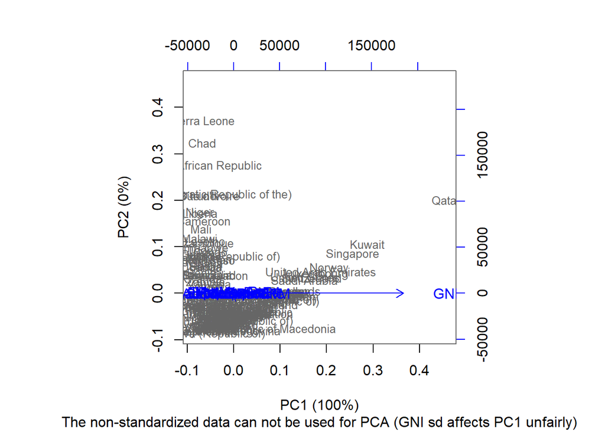

```r
#Run the analysis on non-scaled data
dataPCA <- prcomp(data)

#Call summary
s <- summary(dataPCA)
#Add precetentages
pca_pr <- round(100*s$importance[2,], digits = 1)
#Make label names
pc_lab <- paste0(names(pca_pr), " (", pca_pr, "%)")
#Plot the result with
plotnoSTD <- biplot(dataPCA, cex = c(0.8, 1), col = c("grey40", "blue"), xlab = pc_lab[1], ylab = pc_lab[2],
sub="The non-standardized data can not be used for PCA (GNI sd affects PC1 unfairly)")
```

Let’s scale the data to standardize it and re-run the analysis. This time we will use fviz_pca_biplot() function to make more aesthetically pleasing graph.

```r
#Scale data
data_STD <- scale(data)
library("factoextra")
```

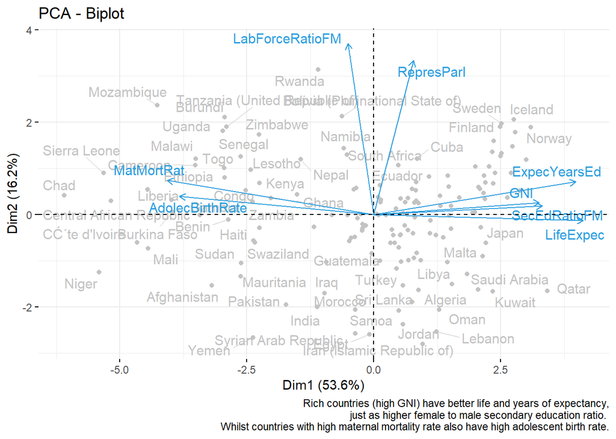

```r
library("FactoMineR")


#Run the analysis
data_STD.pca <- PCA(data_STD, graph = FALSE)

#Make plot
plotSTD <- fviz_pca_biplot(data_STD.pca,  repel = TRUE,
                col.var = "#2E9FDF",
                col.ind = "#c3c3c3")
#Add caption
ggpubr::ggpar(plotSTD, caption = "Rich countries (high GNI) have better life and years of expectancy,
              just as higher female to male secondary education ratio.
              Whilst countries with high maternal mortality rate also have high adolescent birth rate.")
```

The results differ between non-standardized data analysis and standardized data analysis. In the analysis with non-standardized data the principal component explained all of the variance. This is because PCA calculates the new projection based on the standard deviations of the variables in the analysis. In our data set GNI has a very large standard deviation thus it has higher weight on the new projection. Thus to calculate relevant projection standardized data with same deviation is needed.

Almost 70% of the variance in the data is explained by the first two dimensions of the PCA. *ExpecYearsEd*, *GNI*, *SecEdRatioFm* and *LifeExpec* are highly correlated. *MatMortRat* and *AdolecBirthRate* are also highly correlated. These variables are important contributors to the first principal component. To the second component *LabForceRatioFM* and *RepresParl* are the most important contributor. Countries that are close to each other in the biplot represent observations with similar values.

## Multiple Correspondence Analysis

### Data exploration

I will use the tea dataset from the package *FactoMineR* to perform multiple correspondence analysis.

```r
#Load package
library(FactoMineR)
data("tea")
dim(tea)
```

```
## [1] 300  36
```

```r
str(tea)
```

```
## 'data.frame':    300 obs. of  36 variables:
##  $ breakfast       : Factor w/ 2 levels "breakfast","Not.breakfast": 1 1 2 2 1 2 1 2 1 1 ...
##  $ tea.time        : Factor w/ 2 levels "Not.tea time",..: 1 1 2 1 1 1 2 2 2 1 ...
##  $ evening         : Factor w/ 2 levels "evening","Not.evening": 2 2 1 2 1 2 2 1 2 1 ...
##  $ lunch           : Factor w/ 2 levels "lunch","Not.lunch": 2 2 2 2 2 2 2 2 2 2 ...
##  $ dinner          : Factor w/ 2 levels "dinner","Not.dinner": 2 2 1 1 2 1 2 2 2 2 ...
##  $ always          : Factor w/ 2 levels "always","Not.always": 2 2 2 2 1 2 2 2 2 2 ...
##  $ home            : Factor w/ 2 levels "home","Not.home": 1 1 1 1 1 1 1 1 1 1 ...
##  $ work            : Factor w/ 2 levels "Not.work","work": 1 1 2 1 1 1 1 1 1 1 ...
##  $ tearoom         : Factor w/ 2 levels "Not.tearoom",..: 1 1 1 1 1 1 1 1 1 2 ...
##  $ friends         : Factor w/ 2 levels "friends","Not.friends": 2 2 1 2 2 2 1 2 2 2 ...
##  $ resto           : Factor w/ 2 levels "Not.resto","resto": 1 1 2 1 1 1 1 1 1 1 ...
##  $ pub             : Factor w/ 2 levels "Not.pub","pub": 1 1 1 1 1 1 1 1 1 1 ...
##  $ Tea             : Factor w/ 3 levels "black","Earl Grey",..: 1 1 2 2 2 2 2 1 2 1 ...
##  $ How             : Factor w/ 4 levels "alone","lemon",..: 1 3 1 1 1 1 1 3 3 1 ...
```

[output cut: 22 more lines]

Data consists of 300 rows and 36 columns. Data describes how the tea is drunk, how tea is perceived and some personal details about the participants. All variables apart from age are factorial variables. Most of them are binary. Price has 6 levels.

Data visualized here:

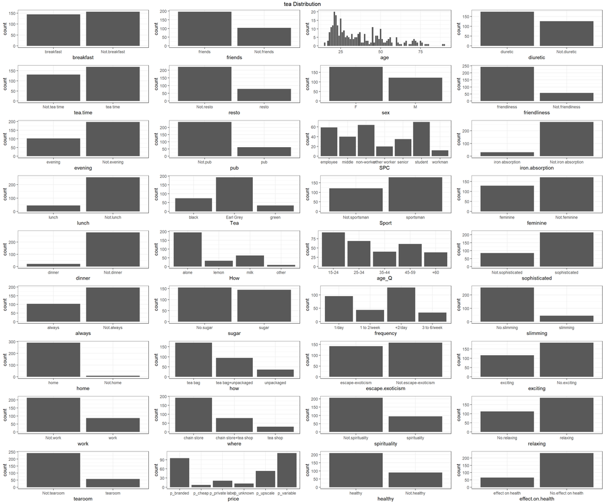

```r
library(mlbench)
library(purrr)
library(ggplot2)
library(gridExtra)

#Read in data
data("tea")

#Automatically plot all of the data
marrangeGrob(
  map(
    names(tea),
    ~ ggplot(tea, aes_string(.x)) +
      geom_bar()+
      theme_bw()
  ),
  ncol = 4,
  nrow = 9,
  top = "tea Distribution"
)
```

### Multiple Correspondence Analysis

```r
#Multiple Correspondence Analysis on the tea data

#Building the model with active variables describing how they drink tea, age variable (19) as quantitative supplementary variable and other variables describing personal details and product perception as qualitative supplementary variables.
teaMCA <- MCA (tea, quanti.sup = 19, quali.sup=c(20:36), graph = FALSE)

#Busy graphs are produced, so adjustments will be made and presented after looking at the summary of the analysis.
```

```r
#First let's check the summary of the model with all categorical variables
summary(teaMCA, nbelements = Inf)
```

```
##
## Call:
## MCA(X = tea, quanti.sup = 19, quali.sup = c(20:36), graph = FALSE)
##
##
## Eigenvalues
##                        Dim.1   Dim.2   Dim.3   Dim.4   Dim.5   Dim.6   Dim.7
## Variance               0.148   0.122   0.090   0.078   0.074   0.071   0.068
## % of var.              9.885   8.103   6.001   5.204   4.917   4.759   4.522
## Cumulative % of var.   9.885  17.988  23.989  29.192  34.109  38.868  43.390
##                        Dim.8   Dim.9  Dim.10  Dim.11  Dim.12  Dim.13  Dim.14
## Variance               0.065   0.062   0.059   0.057   0.054   0.052   0.049
## % of var.              4.355   4.123   3.902   3.805   3.628   3.462   3.250
## Cumulative % of var.  47.745  51.867  55.769  59.574  63.202  66.664  69.914
##                       Dim.15  Dim.16  Dim.17  Dim.18  Dim.19  Dim.20  Dim.21
```

[output cut: 842 more lines]

### Graphical summary

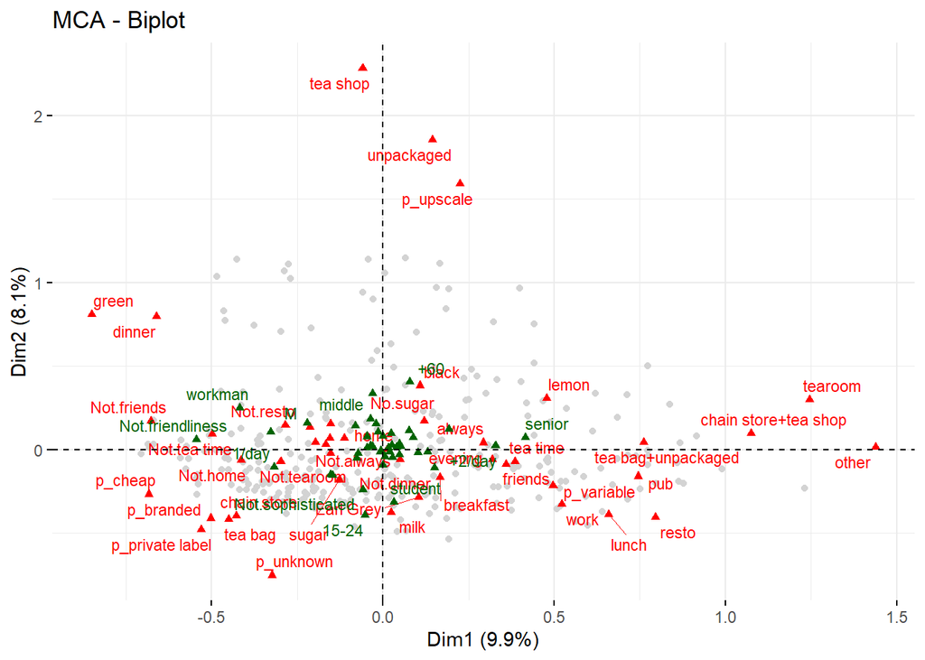

```r
#Variable biplot of the analysis
#Selected
fviz_mca_biplot(teaMCA,label ="var", col.ind="lightgray",
                repel = TRUE,
                labelsize = 3)
```

Since the graph with all of the variable categories is too busy, to visualize the analysis I set the individual data points in the background and in grey color. No clear pattern or grouping emerge in the background individual data points. 18% of data are represented by first two dimensions - components. First component opposes *tearoom*, *resto*,*lunch* and *pub* with *Not.friends*, *Not.home* and *Not.tea time*. Thus opposing individuals who do not regularly drink tea and those who drink tea in many places. Second component distinquish *teashop*, *unpackaged* and *p_upscale* from the rest of the groups, which based on intuition could be true.